# Lista 5 - Series

#### 12. Como o método de estimacao é recursivo, a obtencao dos erros de previsao um passo à frente na massa de validacao pode ser realizada da seguinte forma:

##### 12.1 Aplique o modelo sobre a base de dados completa, usando a funcao sarima do pacote astsa.

```r
# Ajusta o modelo SARIMA na base de dados completa
fitted_model <- sarima(full_data, p = order[1], d = order[2], q = order[3] , seasonal = seasonal_order)
```

```
## <><><><><><><><><><><><><><>
##
## Coefficients:
##          Estimate     SE t.value p.value
## ma1       -0.4935 0.0736 -6.7057  0.0000
## constant   0.0281 0.0511  0.5495  0.5831
##
## sigma^2 estimated as 3.235375 on 318 degrees of freedom
##
## AIC = 4.031644  AICc = 4.031763  BIC = 4.066972
##
```

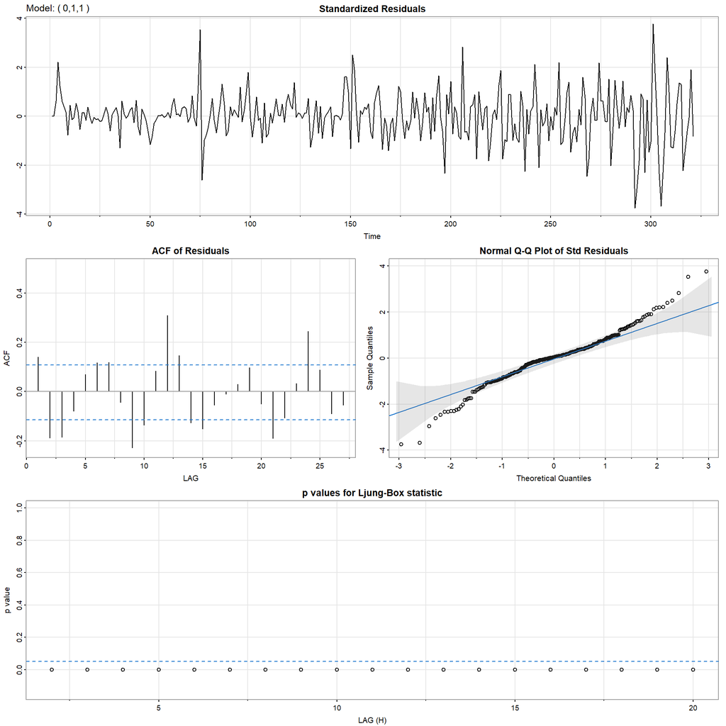

##### 12.2 Obtenha os erros de previsão um passo à frente observados na parte da validação do modelo

```r
# Previsão na base de validação
forecast <- sarima.for(as.ts(full_data), n.ahead=length(validation),
                       p=order[1], d=order[2], q=order[3],
                       P=best_seasonal_order[1], D=best_seasonal_order[2], Q=best_seasonal_order[3], S=best_seasonal_order[4])
```

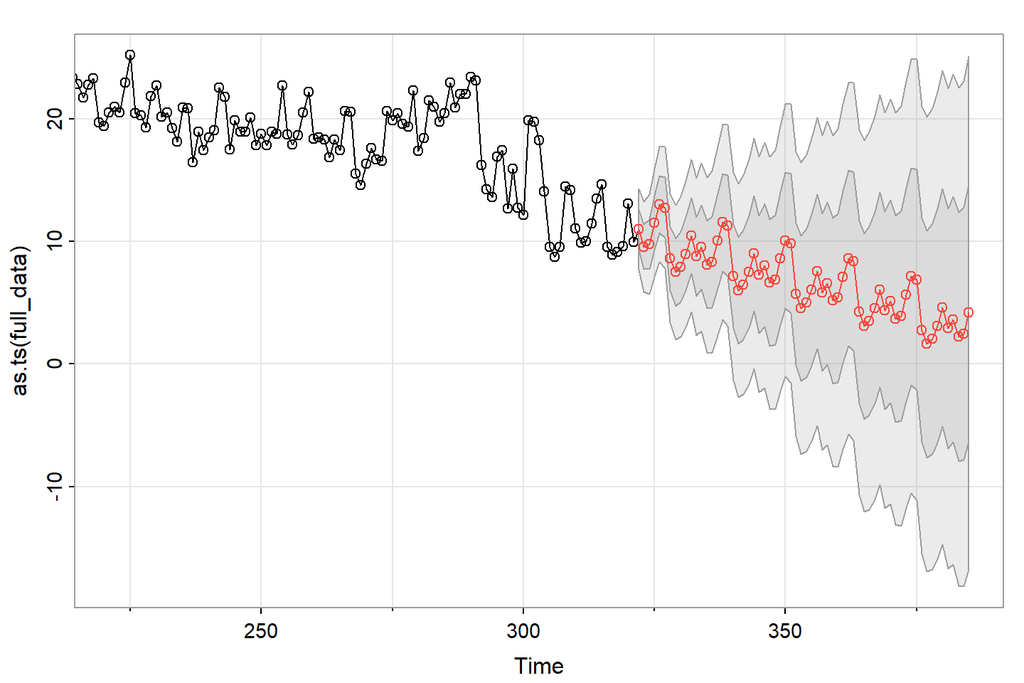

```r
# Calcular os erros de previsão
mse <- mean((validation - forecast$pred)^2)
mae <- mean(abs(validation - forecast$pred))
```

[output not shown]

```
## MSE: 108.395056
```

```
## MAE: 9.684503
```

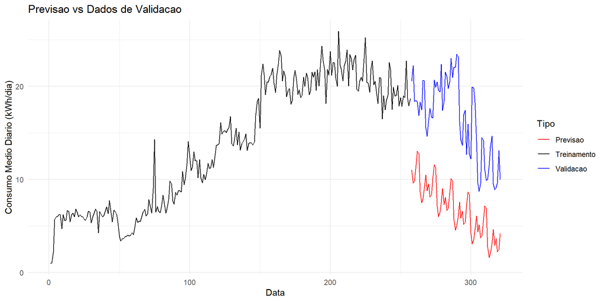

##### 12.3 Calcule um índice de desempenho preditivo. Por exemplo, obtenha o MAPE (mean absolute percentage error)

```r
forecast_mean <- forecast$pred

# Calcular o MAPE
mape <- mean(abs((validation - forecast_mean) / validation))
```

[output not shown]

##### 12.4 Como referência, modelos com MAPE inferiores a 10% geralmente são considerados muito bons. Entre 10% e 20% são bons modelos preditivos, e entre 20% e 50% são modelos razoáveis/aceitáveis.

```r
if (mape < 10) {
  cat("Modelo muito bom.\n")
} else if (mape < 20) {
  cat("Bom modelo preditivo.\n")
} else if (mape < 50) {
  cat("Modelo razoável/aceitável.\n")
} else {
  cat("O modelo precisa ser melhorado.\n")
}
```

[output not shown]

#### 13. Utilize a função sarima.for do pacote astsa para a obtenção de previsões para os próximos 12 meses (ou outro horizonte desejado) e a banda de previsão com 95% de cobertura. Discuta sobre as limitações dessas previsões, incluindo um insigh sobre como proceder se a hipótese de normalidade residual for descartada no passo 11.3.

```r
horizon <- 12

last_date <- tail(df$Ano,n=1)

# Extrair o último mês e ano das datas
last_month <- as.numeric(format(last_date, "%m"))
last_year <- as.numeric(format(last_date, "%Y"))

# Gerar índices de datas para os próximos 12 meses
date_index <- seq(as.Date(paste0(last_year, "-", last_month, "-01")),
                  by = "month", length.out = horizon)

# Realizar a previsão usando o modelo ajustado
forecast <- sarima.for(as.ts(full_data), n.ahead = horizon,
                       p = order[1], d = order[2], q = order[3],
                       P = best_seasonal_order[1], D = best_seasonal_order[2], Q = best_seasonal_order[3],
                       S = best_seasonal_order[4])
```

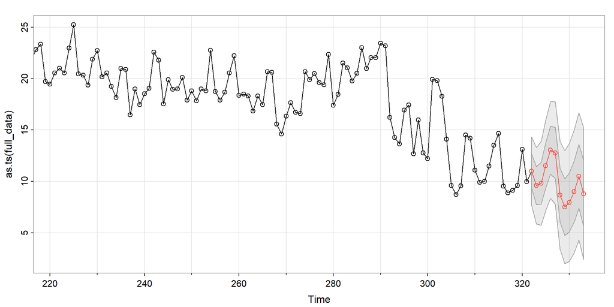

```r
# Extrair valores previstos e intervalos de confiança
forecast_values <- forecast$pred
forecast_conf_int <- forecast$pred + cbind(-1.96 * forecast$se, 1.96 * forecast$se)

# Criar dataframe de previsões
forecast_df <- data.frame(
  Mes = date_index,
  Previsões = forecast_values,
  Limite_Inferior = forecast_conf_int[, 1],
  Limite_Superior = forecast_conf_int[, 2]
)

# Converter coluna de meses para o formato ano-mês
forecast_df$Mes <- format(forecast_df$Mes, "%Y-%m")
```

```
##        Mes Previsões Limite_Inferior Limite_Superior
## 1  2024-02 11.004960        7.742508        14.26741
## 2  2024-03  9.589115        5.946415        13.23181
## 3  2024-04  9.819935        5.833091        13.80678
## 4  2024-05 11.539586        7.236030        15.84314
## 5  2024-06 13.048359        8.449853        17.64686
## 6  2024-07 12.782956        7.907311        17.65860
## 7  2024-08  8.652231        3.514373        13.79009
## 8  2024-09  7.502309        2.114986        12.88963
## 9  2024-10  7.950865        2.325129        13.57660
## 10 2024-11  8.995454        3.141005        14.84990
## 11 2024-12 10.495515        4.420958        16.57007
## 12 2025-01  8.783873        2.496910        15.07084
```